# Gesture Recognition

**Use Tensorflow 2.10.0**

## 1. Data Loader and Analysis

```python
# import library
import os, glob, shutil
import numpy as np
import datetime
import tensorflow as tf
import pandas as pd
from PIL import Image
import cv2
import matplotlib.pyplot as plt
import seaborn as sns
from tqdm import tqdm

from keras.layers import Dense, Dropout, Conv3D, Input, MaxPool3D, Flatten, Activation, \
                         TimeDistributed, BatchNormalization, MaxPooling2D, LSTM, GRU, Conv2D, MaxPooling3D
from keras.regularizers import l2
from keras.models import Model, Sequential

# set random seed for whole project
np.random.seed(1)
tf.random.set_seed(1)
```

```python
# setting global parameter
data_folder = './data'
checkpoints_folder = './checkpoints'

# setting hyparameter for project
batch_size = 8
num_epochs = 50
dest_size = (128, 128)
```

### 1.1 Read CSV file

```python
train_doc = np.random.permutation(open('./data/train.csv').readlines())
val_doc = np.random.permutation(open('./data/val.csv').readlines())
train_df = pd.read_csv(os.path.join(data_folder, 'train.csv'), delimiter=';', names=['video', 'label (text)', 'label'])
val_df   = pd.read_csv(os.path.join(data_folder, 'val.csv'), delimiter=';', names=['video', 'label (text)', 'label'])
print('Total train samples :', len(train_df))
print('Total val samples   :', len(val_df))
```

```
Total train samples : 663
Total val samples   : 100
```

```python
# take a look at train and val
print(train_df.head(5))
print(val_df.head(5))
```

```
                                      video    label (text)  label
0  WIN_20180925_17_08_43_Pro_Left_Swipe_new  Left_Swipe_new      0
1  WIN_20180925_17_18_28_Pro_Left_Swipe_new  Left_Swipe_new      0
2  WIN_20180925_17_18_56_Pro_Left_Swipe_new  Left_Swipe_new      0
3  WIN_20180925_17_19_51_Pro_Left_Swipe_new  Left_Swipe_new      0
4  WIN_20180925_17_20_14_Pro_Left_Swipe_new  Left_Swipe_new      0
                                      video    label (text)  label
0  WIN_20180925_17_17_04_Pro_Left_Swipe_new  Left_Swipe_new      0
1  WIN_20180925_17_43_01_Pro_Left_Swipe_new  Left_Swipe_new      0
2  WIN_20180925_18_01_40_Pro_Left_Swipe_new  Left_Swipe_new      0
3  WIN_20180925_18_03_21_Pro_Left_Swipe_new  Left_Swipe_new      0
4  WIN_20180926_16_46_22_Pro_Left_Swipe_new  Left_Swipe_new      0
```

```python
# create a labels dict with key is numberic and labels is text
label_dict = {
    0 : 'Left Swipe',
    1 : 'Right Swipe',
    2 : 'Stop',
    3 : 'Thumbs Down',
    4 : 'Thumbs Up',
}
```

### 1.2 Analysis data

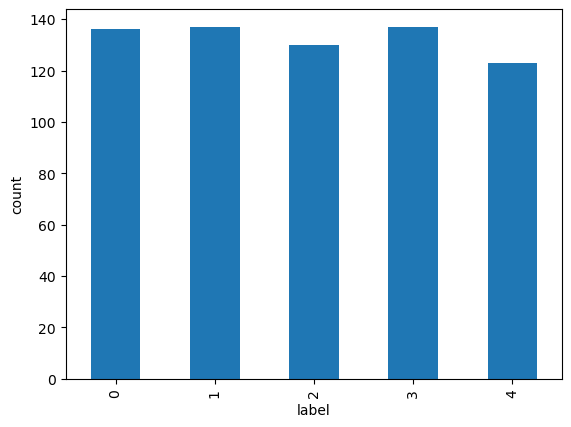

```python
data = train_df.groupby('label').size()
data.plot.bar(xlabel='label', ylabel='count')
```

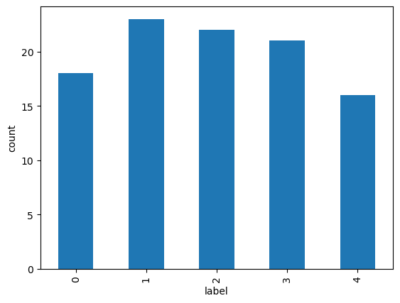

```python
data = val_df.groupby('label').size()
data.plot.bar(xlabel='label', ylabel='count')
```

Conclusion:

Data is quite balance in class

### 1.3 Data Generator and Transform

Cause data is left and right sensitive, up and down sensitive, so it would be better to not clip, rotate it in spatial Cause data is sequence, so we should not random choose the frame order

We can change the contrast and brightness of image https://docs.opencv.org/3.4/d3/dc1/tutorial_basic_linear_transform.html

```python
def resize_img(im, desired_size = dest_size[0]):
    """
        Resize image with keep aspect ratio
    """
    old_size = im.shape[:2] # old_size is in (height, width) format

    ratio = float(desired_size)/max(old_size)
    new_size = tuple([int(x*ratio) for x in old_size])

    # new_size should be in (width, height) format

    im = cv2.resize(im, (new_size[1], new_size[0]))

    delta_w = desired_size - new_size[1]
    delta_h = desired_size - new_size[0]
    top, bottom = delta_h//2, delta_h-(delta_h//2)
    left, right = delta_w//2, delta_w-(delta_w//2)

    color = [0, 0, 0]
    new_im = cv2.copyMakeBorder(im, top, bottom, left, right, cv2.BORDER_CONSTANT, value=color)
    return new_im

def change_brightness(image):
    alpha = np.random.uniform(0.75, 1.25)
    beta = np.random.uniform(0, 100)
    new_image = np.zeros(image.shape, image.dtype)
    for y in range(image.shape[0]):
        for x in range(image.shape[1]):
            for c in range(image.shape[2]):
                new_image[y,x,c] = np.clip(alpha*image[y,x,c] + beta, 0, 255)
    return new_image

def add_noise(image, threshold = 70):
    """
        Add salt and pepper noise if get random int > threshold
    """
    random_value = np.random.randint(0, 100)
    if random_value > threshold:
        image = image/255.0
        row,col,ch = image.shape
        s_vs_p = 0.5
        amount = 0.004
        out = np.copy(image)
        # Salt mode
        num_salt = np.ceil(amount * image.size * s_vs_p)
        coords = [np.random.randint(0, i - 1, int(num_salt))
              for i in image.shape]
        out[coords] = 1

        # Pepper mode
        num_pepper = np.ceil(amount* image.size * (1. - s_vs_p))
        coords = [np.random.randint(0, i - 1, int(num_pepper))
              for i in image.shape]
        out[coords] = 0
        out = image*255
        return out
    else:
        return image
```

```python
from imageio import imread
from skimage.transform import resize

def generator(source_path, folder_list, batch_size, augmentation = False):
    img_idx = [x for x in range(0,30,2)]#create a list of image numbers you want to use for a particular video, we are not using all the 30 images in a video, selected pickup of images
    while True:
        t = np.random.permutation(folder_list)
        num_batches =int(len(t)/batch_size) # calculate the number of batches
        for batch in range(num_batches): # we iterate over the number of batches
            x=len(img_idx)
            y=dest_size[0]
            z=dest_size[1]
            batch_data = np.zeros((batch_size,x,y,z,3)) # x is the number of images you use for each video, (y,z) is the final size of the input images and 3 is the number of channels RGB
            batch_labels = np.zeros((batch_size,5)) # batch_labels is the one hot representation of the output
            cnt_img=0
            for folder in range(batch_size): # iterate over the batch_size
                imgs = sorted(os.listdir(source_path+'/'+ t[folder + (batch*batch_size)].split(';')[0])) # read all the images in the folder
                cnt_img+=1
                for idx,item in enumerate(img_idx): #  Iterate iver the frames/images of a folder to read them in
                    image = cv2.imread(source_path+'/'+ t[folder + (batch*batch_size)].strip().split(';')[0]+'/'+imgs[item])
                    image = cv2.cvtColor(image, cv2.COLOR_BGR2RGB)
                    if augmentation:
                        image = change_brightness(image)
                    #crop the images and resize them. Note that the images are of 2 different shape
                    #and the conv3D will throw error if the inputs in a batch have different shapes
                    image=resize_img(image)
                    image=image/255.0


                    batch_data[folder,idx,:,:,0] = (image[:,:,0])#normalise and feed in the image
                    batch_data[folder,idx,:,:,1] = (image[:,:,1])#normalise and feed in the image
                    batch_data[folder,idx,:,:,2] = (image[:,:,2])#normalise and feed in the image

                batch_labels[folder, int(t[folder + (batch*batch_size)].strip().split(';')[2])] = 1
            yield batch_data, batch_labels #you yield the batch_data and the batch_labels, remember what does yield do


        # write the code for the remaining data points which are left after full batches
        cnt_img=0
        batch_cover = num_batches*batch_size
        rem = len(t) - batch_cover
        if(len(t)!=batch_cover):
            batch_data = np.zeros((rem,x,y,z,3)) # x is the number of images you use for each video, (y,z) is the final size of the input images and 3 is the number of channels RGB
            batch_labels = np.zeros((rem,5)) # batch_labels is the one hot representation of the output
            for folder in range(rem):
                imgs = sorted(os.listdir(source_path+'/'+ t[folder + batch_cover].split(';')[0])) # read all the images in the folder
                cnt_img+=1
                for idx,item in enumerate(img_idx): #  Iterate iver the frames/images of a folder to read them in
                    image = cv2.imread(source_path+'/'+ t[folder + batch_cover].strip().split(';')[0]+'/'+imgs[item])
                    image = cv2.cvtColor(image, cv2.COLOR_BGR2RGB)
                    #crop the images and resize them. Note that the images are of 2 different shape
                    #and the conv3D will throw error if the inputs in a batch have different shapes
                    image=resize_img(image)
                    image=image/255.0


                    batch_data[folder,idx,:,:,0] = (image[:,:,0])#normalise and feed in the image
                    batch_data[folder,idx,:,:,1] = (image[:,:,1])#normalise and feed in the image
                    batch_data[folder,idx,:,:,2] = (image[:,:,2])#normalise and feed in the image

                batch_labels[folder, int(t[folder + batch_size].strip().split(';')[2])] = 1
            yield batch_data, batch_labels #you yield the batch_data and the batch_labels, remember what does yield do
```

```python
curr_dt_time = datetime.datetime.now()
train_path = './data/train'
val_path = './data/val'
num_train_sequences = len(train_df)
print('# training sequences =', num_train_sequences)
num_val_sequences = len(val_df)
print('# validation sequences =', num_val_sequences)
print ('# epochs =', num_epochs)
```

```
# training sequences = 663
# validation sequences = 100
# epochs = 50
```

## Model buiding

```python
def train_model(model, name, num_epochs = num_epochs, batch_size = batch_size, load_lastest = True):
    # train and val generator
    train_generator = generator(train_path, train_doc, batch_size)
    val_generator = generator(val_path, val_doc, batch_size)

    # create folder for saving checkpoints
    model_name = 'model' + '_' + name

    if not os.path.exists(os.path.join(checkpoints_folder, model_name)):
        os.mkdir(os.path.join(checkpoints_folder, model_name))

    # optimizers
#     opt = tf.keras.optimizers.Adam(learning_rate=0.001,
#                                    beta_1=0.9,
#                                    beta_2=0.999,
#                                    epsilon=1e-07,
#                                    amsgrad=False,
#                                    name='Adam'
#                                   )
#     model.compile(optimizer=opt, loss='categorical_crossentropy', metrics=['categorical_accuracy'])
    optimiser = "Adam" #write your optimizer
    model.compile(optimizer=optimiser, loss='categorical_crossentropy', metrics=['categorical_accuracy'])
    print("###############################################")
    print("Model {} summary".format(name))
    print(model.summary())
    print("###############################################")

    # callbacks
    filepath = model_name + '-{epoch:05d}-{loss:.5f}-{categorical_accuracy:.5f}-{val_loss:.5f}-{val_categorical_accuracy:.5f}.h5'
    checkpoint = tf.keras.callbacks.ModelCheckpoint(os.path.join(checkpoints_folder, model_name, filepath),
                                                                 monitor='val_loss',
                                                                 verbose=1,
                                                                 save_best_only=True,
                                                                 save_weights_only=False,
                                                                 mode='auto',
                                                                 period=1) #chekpoints to save model in .h5
    LR = tf.keras.callbacks.ReduceLROnPlateau(monitor='val_loss', factor=0.1, patience=10, cooldown=5, verbose=1,mode='auto',min_delta=0.00001) #learning Rate
    callbacks_list = [checkpoint, LR]

    # calculate step_per_epoch
    if (num_train_sequences%batch_size) == 0:
        steps_per_epoch = int(num_train_sequences/batch_size)
    else:
        steps_per_epoch = (num_train_sequences//batch_size) + 1 #in case of remaining data points which are left after full batches

    if (num_val_sequences%batch_size) == 0:
        validation_steps = int(num_val_sequences/batch_size)
    else:
        validation_steps = (num_val_sequences//batch_size) + 1 #in case of remaining data points which are left after full batches

    # Training process
    print("###############################################")
    print("Training model")

    init_epoch = 0
    if load_lastest:
        model_lastest_path = sorted(glob.glob(os.path.join(checkpoints_folder, model_name, "*")))
        if len(model_lastest_path) != 0:
            model_lastest_path = model_lastest_path[-1]
            epoch_lastest = int(os.path.basename(model_lastest_path).split('-')[1])
            init_epoch = epoch_lastest
            print("Loading model from epoch:", init_epoch)
            model = tf.keras.models.load_model(model_lastest_path)

    history=model.fit(train_generator,
                      steps_per_epoch=steps_per_epoch,
                      epochs=num_epochs, verbose=1,
                      callbacks=callbacks_list,
                      validation_data=val_generator,
                      validation_steps=validation_steps,
                      class_weight=None,
                      workers=1,
                      initial_epoch=init_epoch)
    print("###############################################")
    return history
```

```python
# plot accuracy & loss
def plot_history(history):
    fig, axes = plt.subplots(nrows=1, ncols=2, figsize=(15,4))
    axes[0].plot(history.history['loss'])
    axes[0].plot(history.history['val_loss'])
    axes[0].legend(['loss','val_loss'])

    axes[1].plot(history.history['categorical_accuracy'])
    axes[1].plot(history.history['val_categorical_accuracy'])
    axes[1].legend(['categorical_accuracy','val_categorical_accuracy'])
```

## 2.1 3D CNN Model

### 2.1.1 C3D

C3D inspired model

```python
def Model_3D_01(nb_classes):
    """
        C3D Model
    """
    input_shape = (15, 128, 128, 3)
    weight_decay = 0.005
    nb_classes = nb_classes

    inputs = Input(input_shape)
    x = Conv3D(32,(3,3,3),strides=(1,1,1),padding='same',
               activation='relu',kernel_regularizer=l2(weight_decay))(inputs)
    x = MaxPool3D((1,2,2),strides=(1,2,2),padding='same')(x)

    x = Conv3D(64,(3,3,3),strides=(1,1,1),padding='same',
               activation='relu',kernel_regularizer=l2(weight_decay))(x)
    x = MaxPool3D((2,2,2),strides=(2,2,2),padding='same')(x)

    x = Conv3D(64,(3,3,3),strides=(1,1,1),padding='same',
               activation='relu',kernel_regularizer=l2(weight_decay))(x)
    x = MaxPool3D((2,2,2),strides=(2,2,2),padding='same')(x)

    x = Conv3D(128,(3,3,3),strides=(1,1,1),padding='same',
               activation='relu',kernel_regularizer=l2(weight_decay))(x)
    x = MaxPool3D((2,2,2),strides=(2,2,2),padding='same')(x)

    x = Conv3D(128, (3, 3, 3), strides=(1, 1, 1), padding='same',
               activation='relu',kernel_regularizer=l2(weight_decay))(x)
    x = MaxPool3D((2, 2, 2), strides=(2, 2, 2), padding='same')(x)

    x = Flatten()(x)
    x = Dense(1024,activation='relu',kernel_regularizer=l2(weight_decay))(x)
    x = Dropout(0.5)(x)
    x = Dense(128,activation='relu',kernel_regularizer=l2(weight_decay))(x)
    x = Dropout(0.5)(x)
    x = Dense(nb_classes,kernel_regularizer=l2(weight_decay))(x)
    x = Activation('softmax')(x)

    model = Model(inputs, x, name = "3D_01")
    return model
```

```
###############################################
Model 3D_01 summary
Model: "3D_01"
_________________________________________________________________
 Layer (type)                Output Shape              Param #
=================================================================
 input_1 (InputLayer)        [(None, 15, 128, 128, 3)  0
                             ]

 conv3d (Conv3D)             (None, 15, 128, 128, 32)  2624

 max_pooling3d (MaxPooling3D  (None, 15, 64, 64, 32)   0
 )

 conv3d_1 (Conv3D)           (None, 15, 64, 64, 64)    55360

 max_pooling3d_1 (MaxPooling  (None, 8, 32, 32, 64)    0
 3D)

 conv3d_2 (Conv3D)           (None, 8, 32, 32, 64)     110656

 max_pooling3d_2 (MaxPooling  (None, 4, 16, 16, 64)    0
 3D)

 conv3d_3 (Conv3D)           (None, 4, 16, 16, 128)    221312

 max_pooling3d_3 (MaxPooling  (None, 2, 8, 8, 128)     0
 3D)

 conv3d_4 (Conv3D)           (None, 2, 8, 8, 128)      442496

 max_pooling3d_4 (MaxPooling  (None, 1, 4, 4, 128)     0
 3D)

 flatten (Flatten)           (None, 2048)              0

 dense (Dense)               (None, 1024)              2098176

 dropout (Dropout)           (None, 1024)              0

```

[output cut: 58 more lines]

```
Epoch 39: val_loss did not improve from 1.60546
Epoch 40: val_loss did not improve from 1.60546
Epoch 41: val_loss did not improve from 1.60546
Epoch 42: val_loss did not improve from 1.60546
Epoch 43: val_loss did not improve from 1.60546

Epoch 43: ReduceLROnPlateau reducing learning rate to 1.0000000474974514e-05.
Epoch 44: val_loss did not improve from 1.60546
Epoch 45: val_loss improved from 1.60546 to 1.60467, saving model to ./checkpoints\model_3D_01\model_3D_01-00045-1.60887-0.20664-1.60467-0.23000.h5
Epoch 46: val_loss did not improve from 1.60467
Epoch 47: val_loss did not improve from 1.60467
Epoch 48: val_loss did not improve from 1.60467
Epoch 49: val_loss did not improve from 1.60467
Epoch 50: val_loss did not improve from 1.60467
###############################################
```

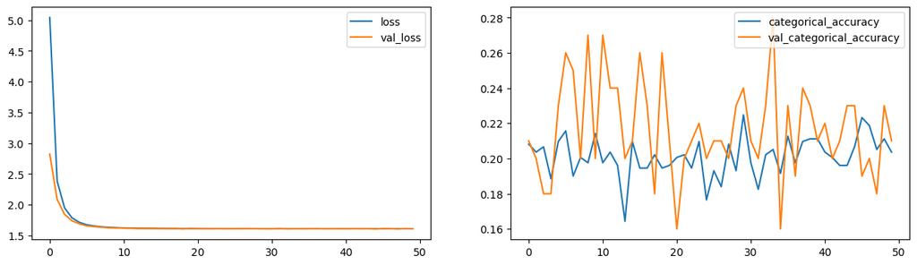

```python
model = Model_3D_01(nb_classes = 5)
history = train_model(model, name = '3D_01')
plot_history(history)
```

Highest val_acc: at epoch 34: acc: 0.2051, val_acc: 0.2800

### 2.1.2 VGG Like 3D

What if 3D CNN go with VGG like (2 conv + 1 pool)

```python
def Model_3D_02(nb_classes):
    """
        C3D Model
    """
    input_shape = (15, 128, 128, 3)
    weight_decay = 0.005
    nb_classes = nb_classes

    inputs = Input(input_shape)
    # block 1
    x = Conv3D(32,(3,3,3),strides=(1,1,1),padding='same',
               activation='relu',kernel_regularizer=l2(weight_decay))(inputs)
    x = Conv3D(32,(3,3,3),strides=(1,1,1),padding='same',
               activation='relu',kernel_regularizer=l2(weight_decay))(x)
    x = MaxPool3D((1,2,2),strides=(1,2,2),padding='same')(x)

    # block 2
    x = Conv3D(64,(3,3,3),strides=(1,1,1),padding='same',
               activation='relu',kernel_regularizer=l2(weight_decay))(x)
    x = Conv3D(64,(3,3,3),strides=(1,1,1),padding='same',
               activation='relu',kernel_regularizer=l2(weight_decay))(x)
    x = MaxPool3D((2,2,2),strides=(2,2,2),padding='same')(x)

    # block 3
    x = Conv3D(64,(3,3,3),strides=(1,1,1),padding='same',
               activation='relu',kernel_regularizer=l2(weight_decay))(x)
    x = Conv3D(64,(3,3,3),strides=(1,1,1),padding='same',
               activation='relu',kernel_regularizer=l2(weight_decay))(x)
    x = MaxPool3D((2,2,2),strides=(2,2,2),padding='same')(x)

    # block 4
    x = Conv3D(128,(3,3,3),strides=(1,1,1),padding='same',
               activation='relu',kernel_regularizer=l2(weight_decay))(x)
    x = Conv3D(128,(3,3,3),strides=(1,1,1),padding='same',
               activation='relu',kernel_regularizer=l2(weight_decay))(x)
    x = MaxPool3D((2,2,2),strides=(2,2,2),padding='same')(x)

    # block 5
    x = Conv3D(128, (3, 3, 3), strides=(1, 1, 1), padding='same',
               activation='relu',kernel_regularizer=l2(weight_decay))(x)
    x = MaxPool3D((2, 2, 2), strides=(2, 2, 2), padding='same')(x)

    x = Flatten()(x)
    x = Dense(1024,activation='relu',kernel_regularizer=l2(weight_decay))(x)
    x = Dropout(0.5)(x)
    x = Dense(128,activation='relu',kernel_regularizer=l2(weight_decay))(x)
    x = Dropout(0.5)(x)
    x = Dense(nb_classes,kernel_regularizer=l2(weight_decay))(x)
    x = Activation('softmax')(x)

    model = Model(inputs, x, name = '3D_02')
    return model
```

```
###############################################
Model 3D_02 summary
Model: "3D_02"
_________________________________________________________________
 Layer (type)                Output Shape              Param #
=================================================================
 input_2 (InputLayer)        [(None, 15, 128, 128, 3)  0
                             ]

 conv3d_5 (Conv3D)           (None, 15, 128, 128, 32)  2624

 conv3d_6 (Conv3D)           (None, 15, 128, 128, 32)  27680

 max_pooling3d_5 (MaxPooling  (None, 15, 64, 64, 32)   0
 3D)

 conv3d_7 (Conv3D)           (None, 15, 64, 64, 64)    55360

 conv3d_8 (Conv3D)           (None, 15, 64, 64, 64)    110656

 max_pooling3d_6 (MaxPooling  (None, 8, 32, 32, 64)    0
 3D)

 conv3d_9 (Conv3D)           (None, 8, 32, 32, 64)     110656

 conv3d_10 (Conv3D)          (None, 8, 32, 32, 64)     110656

 max_pooling3d_7 (MaxPooling  (None, 4, 16, 16, 64)    0
 3D)

 conv3d_11 (Conv3D)          (None, 4, 16, 16, 128)    221312

 conv3d_12 (Conv3D)          (None, 4, 16, 16, 128)    442496

 max_pooling3d_8 (MaxPooling  (None, 2, 8, 8, 128)     0
 3D)

 conv3d_13 (Conv3D)          (None, 2, 8, 8, 128)      442496

 max_pooling3d_9 (MaxPooling  (None, 1, 4, 4, 128)     0
```

[output cut: 66 more lines]

```
Epoch 39: val_loss did not improve from 1.60360
Epoch 40: val_loss did not improve from 1.60360
Epoch 41: val_loss did not improve from 1.60360
Epoch 42: val_loss did not improve from 1.60360
Epoch 43: val_loss did not improve from 1.60360
Epoch 44: val_loss did not improve from 1.60360
Epoch 45: val_loss did not improve from 1.60360
Epoch 46: val_loss did not improve from 1.60360
Epoch 47: val_loss did not improve from 1.60360

Epoch 47: ReduceLROnPlateau reducing learning rate to 1.0000000474974514e-05.
Epoch 48: val_loss did not improve from 1.60360
Epoch 49: val_loss did not improve from 1.60360
Epoch 50: val_loss did not improve from 1.60360
###############################################
```

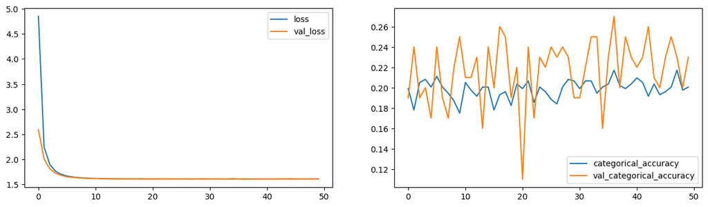

```python
model = Model_3D_02(nb_classes = 5)
history = train_model(model, name = '3D_02')
plot_history(history)
```

### 2.1.2 Custom 3D CNN Model

```python
def Model_3D_03(nb_classes):
    """
        Custom 3D Model
    """
    nb_classes = nb_classes
    input_shape = (15, 128, 128, 3)

    model = Sequential(name = "3D_03")

    model.add(Conv3D(16, (3, 3, 3), padding = 'same', input_shape = input_shape))
    model.add(Activation('relu'))
    model.add(BatchNormalization())
    model.add(MaxPooling3D(pool_size = (2, 2, 2)))
    model.add(Dropout(0.25))

    model.add(Conv3D(32, (2, 2, 2), padding = 'same'))
    model.add(Activation('relu'))
    model.add(BatchNormalization())
    model.add(MaxPooling3D(pool_size = (2, 2, 2)))

    model.add(Conv3D(64, (2, 2, 2), padding = 'same'))
    model.add(Activation('relu'))
    model.add(BatchNormalization())
    model.add(MaxPooling3D(pool_size = (2, 2, 2)))
    model.add(Dropout(0.25))

    model.add(Flatten())

    model.add(Dense(64, activation='relu',kernel_regularizer=l2(0.01)))
    model.add(Dropout(0.25))

    model.add(Dense(32, activation='relu',kernel_regularizer=l2(0.01)))
    model.add(Dropout(0.25))


     # using Softmax as last layer
    model.add(Dense(nb_classes, activation='softmax'))
    return model
```

```
###############################################
Model 3D_03 summary
Model: "3D_03"
_________________________________________________________________
 Layer (type)                Output Shape              Param #
=================================================================
 conv3d_15 (Conv3D)          (None, 15, 128, 128, 16)  1312

 activation_3 (Activation)   (None, 15, 128, 128, 16)  0

 batch_normalization_1 (Batc  (None, 15, 128, 128, 16)  64
 hNormalization)

 max_pooling3d_10 (MaxPoolin  (None, 7, 64, 64, 16)    0
 g3D)

 dropout_5 (Dropout)         (None, 7, 64, 64, 16)     0

 conv3d_16 (Conv3D)          (None, 7, 64, 64, 32)     4128

 activation_4 (Activation)   (None, 7, 64, 64, 32)     0

 batch_normalization_2 (Batc  (None, 7, 64, 64, 32)    128
 hNormalization)

 max_pooling3d_11 (MaxPoolin  (None, 3, 32, 32, 32)    0
 g3D)

 conv3d_17 (Conv3D)          (None, 3, 32, 32, 64)     16448

 activation_5 (Activation)   (None, 3, 32, 32, 64)     0

 batch_normalization_3 (Batc  (None, 3, 32, 32, 64)    256
 hNormalization)

 max_pooling3d_12 (MaxPoolin  (None, 1, 16, 16, 64)    0
 g3D)

 dropout_6 (Dropout)         (None, 1, 16, 16, 64)     0

```

[output cut: 60 more lines]

```
Epoch 37: ReduceLROnPlateau reducing learning rate to 0.00010000000474974513.
Epoch 38: val_loss did not improve from 1.20254
Epoch 39: val_loss did not improve from 1.20254
Epoch 40: val_loss did not improve from 1.20254
Epoch 41: val_loss did not improve from 1.20254
Epoch 42: val_loss did not improve from 1.20254
Epoch 43: val_loss did not improve from 1.20254
Epoch 44: val_loss did not improve from 1.20254
Epoch 45: val_loss did not improve from 1.20254
Epoch 46: val_loss improved from 1.20254 to 1.11387, saving model to ./checkpoints\model_3D_03\model_3D_03-00046-0.61341-0.97587-1.11387-0.86000.h5
Epoch 47: val_loss did not improve from 1.11387
Epoch 48: val_loss did not improve from 1.11387
Epoch 49: val_loss did not improve from 1.11387
Epoch 50: val_loss did not improve from 1.11387
###############################################
```

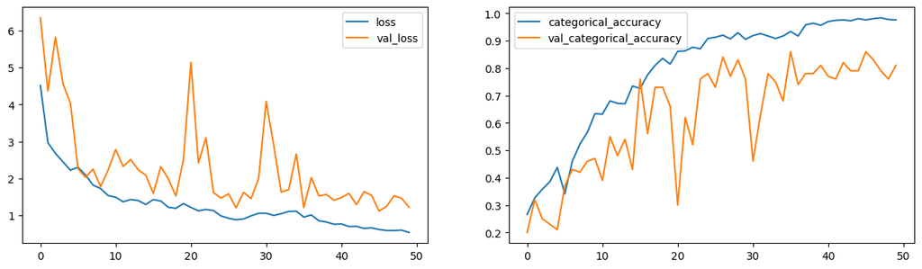

```python
model = Model_3D_03(nb_classes = 5)
history = train_model(model, name = '3D_03')
plot_history(history)
```

Highest val_acc: at epoch 46: acc: 0.9759, val_acc: 0.8600

## 2.2 Custom 2D CNN + LTSM/GRU

### 2.2.1 Cutom 2D CNN + LSTM

```python
def Model_2D_01(nb_classes):
    """
        Custom CNN with LSTM
    """
    nb_classes = nb_classes
    Input_shape_1 = (15, 128, 128, 3)
    model = Sequential(name = "2D_01")
    model.add(TimeDistributed(Conv2D(32, (7, 7), strides=(2, 2), activation='relu', padding='same'), input_shape=Input_shape_1))
    model.add(TimeDistributed(Conv2D(32, (3,3), kernel_initializer="he_normal", activation='relu')))
    model.add(TimeDistributed(MaxPooling2D((2, 2), strides=(2, 2))))

    model.add(TimeDistributed(Conv2D(64, (3,3), padding='same', activation='relu')))
    model.add(TimeDistributed(Conv2D(64, (3,3), padding='same', activation='relu')))
    model.add(TimeDistributed(MaxPooling2D((2, 2), strides=(2, 2))))

    model.add(TimeDistributed(Conv2D(128, (3,3), padding='same', activation='relu')))
    model.add(TimeDistributed(Conv2D(128, (3,3), padding='same', activation='relu')))
    model.add(TimeDistributed(MaxPooling2D((2, 2), strides=(2, 2))))

    model.add(TimeDistributed(Conv2D(256, (3,3), padding='same', activation='relu')))
    model.add(TimeDistributed(Conv2D(256, (3,3), padding='same', activation='relu')))
    model.add(TimeDistributed(MaxPooling2D((2, 2), strides=(2, 2))))

    model.add(TimeDistributed(Conv2D(512, (3,3), padding='same', activation='relu')))
    model.add(TimeDistributed(Conv2D(512, (3,3), padding='same', activation='relu')))
    model.add(TimeDistributed(MaxPooling2D((2, 2), strides=(2, 2))))

    model.add(TimeDistributed(Flatten()))

    model.add(Dropout(0.5))
    model.add(LSTM(512, return_sequences=False, dropout=0.5))
    model.add(Dense(nb_classes, activation='softmax'))
    return model
```

```
###############################################
Model 2D_01 summary
Model: "2D_01"
_________________________________________________________________
 Layer (type)                Output Shape              Param #
=================================================================
 time_distributed_16 (TimeDi  (None, 15, 64, 64, 32)   4736
 stributed)

 time_distributed_17 (TimeDi  (None, 15, 62, 62, 32)   9248
 stributed)

 time_distributed_18 (TimeDi  (None, 15, 31, 31, 32)   0
 stributed)

 time_distributed_19 (TimeDi  (None, 15, 31, 31, 64)   18496
 stributed)

 time_distributed_20 (TimeDi  (None, 15, 31, 31, 64)   36928
 stributed)

 time_distributed_21 (TimeDi  (None, 15, 15, 15, 64)   0
 stributed)

 time_distributed_22 (TimeDi  (None, 15, 15, 15, 128)  73856
 stributed)

 time_distributed_23 (TimeDi  (None, 15, 15, 15, 128)  147584
 stributed)

 time_distributed_24 (TimeDi  (None, 15, 7, 7, 128)    0
 stributed)

 time_distributed_25 (TimeDi  (None, 15, 7, 7, 256)    295168
 stributed)

 time_distributed_26 (TimeDi  (None, 15, 7, 7, 256)    590080
 stributed)

 time_distributed_27 (TimeDi  (None, 15, 3, 3, 256)    0
```

[output cut: 70 more lines]

```
Epoch 37: val_loss did not improve from 1.60342
Epoch 38: val_loss did not improve from 1.60342
Epoch 39: val_loss did not improve from 1.60342
Epoch 40: val_loss did not improve from 1.60342
Epoch 41: val_loss did not improve from 1.60342
Epoch 42: val_loss did not improve from 1.60342
Epoch 43: val_loss did not improve from 1.60342
Epoch 44: val_loss did not improve from 1.60342
Epoch 45: val_loss did not improve from 1.60342
Epoch 46: val_loss did not improve from 1.60342
Epoch 47: val_loss did not improve from 1.60342
Epoch 48: val_loss improved from 1.60342 to 1.60296, saving model to ./checkpoints\model_2D_01\model_2D_01-00048-1.60839-0.20664-1.60296-0.25000.h5
Epoch 49: val_loss did not improve from 1.60296
Epoch 50: val_loss did not improve from 1.60296
###############################################
```

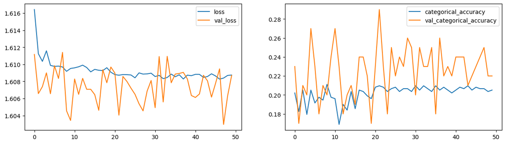

```python
model = Model_2D_01(nb_classes = 5)
history = train_model(model, name = '2D_01')
plot_history(history)
```

Highest val_acc: at epoch 22: acc: 0.2097, val_acc: 0.2900

### 2.2.2 Custom 2D CNN +GRU

```python
def Model_2D_02(nb_classes):
    """
        Custom CNN with GRU
    """
    nb_classes = nb_classes
    Input_shape_1 = (15, 128, 128, 3)
    model = Sequential(name = "2D_02")
    model.add(TimeDistributed(Conv2D(8, (7, 7), strides=(2, 2), activation='relu', padding='same'), input_shape=Input_shape_1))
    model.add(TimeDistributed(Conv2D(8, (3,3), kernel_initializer="he_normal", activation='relu')))
    model.add(TimeDistributed(MaxPooling2D((2, 2), strides=(2, 2))))

    model.add(TimeDistributed(Conv2D(16, (3,3), padding='same', activation='relu')))
    model.add(TimeDistributed(Conv2D(16, (3,3), padding='same', activation='relu')))
    model.add(TimeDistributed(MaxPooling2D((2, 2), strides=(2, 2))))

    model.add(TimeDistributed(Conv2D(32, (3,3), padding='same', activation='relu')))
    model.add(TimeDistributed(Conv2D(32, (3,3), padding='same', activation='relu')))
    model.add(TimeDistributed(MaxPooling2D((2, 2), strides=(2, 2))))

    model.add(TimeDistributed(Conv2D(64, (3,3), padding='same', activation='relu')))
    model.add(TimeDistributed(Conv2D(64, (3,3), padding='same', activation='relu')))
    model.add(TimeDistributed(MaxPooling2D((2, 2), strides=(2, 2))))

    model.add(TimeDistributed(Conv2D(128, (3,3), padding='same', activation='relu')))
    model.add(TimeDistributed(Conv2D(128, (3,3), padding='same', activation='relu')))
    model.add(TimeDistributed(MaxPooling2D((2, 2), strides=(2, 2))))

    model.add(TimeDistributed(Flatten()))

    model.add(Dropout(0.5))
    ## using GRU as the RNN model along with softmax as our last layer.
    model.add(GRU(512, return_sequences=False, dropout=0.5))
    model.add(Dense(nb_classes, activation='softmax'))
    return model
```

```
###############################################
Model 2D_02 summary
Model: "2D_02"
_________________________________________________________________
 Layer (type)                Output Shape              Param #
=================================================================
 time_distributed_32 (TimeDi  (None, 15, 64, 64, 8)    1184
 stributed)

 time_distributed_33 (TimeDi  (None, 15, 62, 62, 8)    584
 stributed)

 time_distributed_34 (TimeDi  (None, 15, 31, 31, 8)    0
 stributed)

 time_distributed_35 (TimeDi  (None, 15, 31, 31, 16)   1168
 stributed)

 time_distributed_36 (TimeDi  (None, 15, 31, 31, 16)   2320
 stributed)

 time_distributed_37 (TimeDi  (None, 15, 15, 15, 16)   0
 stributed)

 time_distributed_38 (TimeDi  (None, 15, 15, 15, 32)   4640
 stributed)

 time_distributed_39 (TimeDi  (None, 15, 15, 15, 32)   9248
 stributed)

 time_distributed_40 (TimeDi  (None, 15, 7, 7, 32)     0
 stributed)

 time_distributed_41 (TimeDi  (None, 15, 7, 7, 64)     18496
 stributed)

 time_distributed_42 (TimeDi  (None, 15, 7, 7, 64)     36928
 stributed)

 time_distributed_43 (TimeDi  (None, 15, 3, 3, 64)     0
```

[output cut: 72 more lines]

```
Epoch 39: val_loss did not improve from 1.60407
Epoch 40: val_loss did not improve from 1.60407
Epoch 41: val_loss did not improve from 1.60407
Epoch 42: val_loss did not improve from 1.60407
Epoch 43: val_loss did not improve from 1.60407
Epoch 44: val_loss did not improve from 1.60407
Epoch 45: val_loss did not improve from 1.60407
Epoch 46: val_loss did not improve from 1.60407

Epoch 46: ReduceLROnPlateau reducing learning rate to 1.0000000656873453e-06.
Epoch 47: val_loss did not improve from 1.60407
Epoch 48: val_loss did not improve from 1.60407
Epoch 49: val_loss improved from 1.60407 to 1.60376, saving model to ./checkpoints\model_2D_02\model_2D_02-00049-1.60863-0.20965-1.60376-0.24000.h5
Epoch 50: val_loss did not improve from 1.60376
###############################################
```

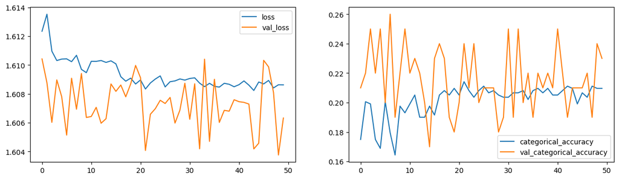

```python
model = Model_2D_02(nb_classes = 5)
history = train_model(model, name = '2D_02')
plot_history(history)
```

### 2.2.3 Another custom 2D CNN +GRU

```python
def Model_2D_03(nb_classes):
    """
        Another custom CNN with GRU
    """
    nb_classes = nb_classes
    input_shape = (15, 128, 128, 3)
    model = Sequential(name = "2D_03")

    model.add(TimeDistributed(Conv2D(16, (3, 3), strides=(2, 2),activation='relu', padding='same'), input_shape=input_shape))
    model.add(TimeDistributed(BatchNormalization()))
    model.add(TimeDistributed(MaxPooling2D((2, 2), strides=(2, 2))))
    model.add(Dropout(0.25))

    model.add(TimeDistributed(Conv2D(32, (3,3),padding='same', activation='relu')))
    model.add(TimeDistributed(BatchNormalization()))
    model.add(TimeDistributed(MaxPooling2D((2, 2), strides=(2, 2))))

    model.add(TimeDistributed(Conv2D(64, (3,3),padding='same', activation='relu')))
    model.add(TimeDistributed(BatchNormalization()))
    model.add(TimeDistributed(MaxPooling2D((2, 2), strides=(2, 2))))
    model.add(Dropout(0.25))

    model.add(TimeDistributed(Conv2D(128, (2,2),padding='same', activation='relu')))
    model.add(TimeDistributed(BatchNormalization()))
    model.add(TimeDistributed(MaxPooling2D((2, 2), strides=(2, 2))))

    model.add(TimeDistributed(Flatten()))

    model.add(Dense(64, activation='relu', kernel_regularizer=l2(0.01)))
    model.add(Dense(32, activation='relu', kernel_regularizer=l2(0.01)))
    model.add(Dropout(0.25))

    ## using GRU as the RNN model along with softmax as our last layer.
    model.add(GRU(64, return_sequences=False))
    model.add(Dropout(0.25))

    # using Softmax as last layer
    model.add(Dense(nb_classes, activation='softmax'))
    return model
```

```
###############################################
Model 2D_03 summary
Model: "2D_03"
_________________________________________________________________
 Layer (type)                Output Shape              Param #
=================================================================
 time_distributed_64 (TimeDi  (None, 15, 64, 64, 16)   448
 stributed)

 time_distributed_65 (TimeDi  (None, 15, 64, 64, 16)   64
 stributed)

 time_distributed_66 (TimeDi  (None, 15, 32, 32, 16)   0
 stributed)

 dropout_14 (Dropout)        (None, 15, 32, 32, 16)    0

 time_distributed_67 (TimeDi  (None, 15, 32, 32, 32)   4640
 stributed)

 time_distributed_68 (TimeDi  (None, 15, 32, 32, 32)   128
 stributed)

 time_distributed_69 (TimeDi  (None, 15, 16, 16, 32)   0
 stributed)

 time_distributed_70 (TimeDi  (None, 15, 16, 16, 64)   18496
 stributed)

 time_distributed_71 (TimeDi  (None, 15, 16, 16, 64)   256
 stributed)

 time_distributed_72 (TimeDi  (None, 15, 8, 8, 64)     0
 stributed)

 dropout_15 (Dropout)        (None, 15, 8, 8, 64)      0

 time_distributed_73 (TimeDi  (None, 15, 8, 8, 128)    32896
 stributed)

```

[output cut: 69 more lines]

```
Epoch 39: val_loss did not improve from 0.59525
Epoch 40: val_loss did not improve from 0.59525
Epoch 41: val_loss did not improve from 0.59525
Epoch 42: val_loss did not improve from 0.59525
Epoch 43: val_loss did not improve from 0.59525
Epoch 44: val_loss did not improve from 0.59525
Epoch 45: val_loss did not improve from 0.59525
Epoch 46: val_loss did not improve from 0.59525
Epoch 47: val_loss did not improve from 0.59525
Epoch 48: val_loss did not improve from 0.59525

Epoch 48: ReduceLROnPlateau reducing learning rate to 0.00010000000474974513.
Epoch 49: val_loss improved from 0.59525 to 0.55812, saving model to ./checkpoints\model_2D_03\model_2D_03-00049-0.19571-0.97888-0.55812-0.85000.h5
Epoch 50: val_loss improved from 0.55812 to 0.46547, saving model to ./checkpoints\model_2D_03\model_2D_03-00050-0.17543-0.99095-0.46547-0.87000.h5
###############################################
```

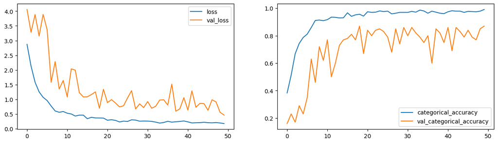

```python
model = Model_2D_03(nb_classes = 5)
history = train_model(model, name = '2D_03')
plot_history(history)
```

Highest val_acc: at epoch 50: acc: 0.9910, val_acc: 0.8700

## 2.3 Pretrained model with LSTM/GRU

### 2.3.1 VGG16 + GRU

```python
def Model_Pretrained_01(nb_classes):
    """
        VGG 16 + GRU
    """
    input_shape = (15, 128, 128, 3)
    weight_decay = 0.005
    nb_classes = nb_classes

    # load VGG16 and freeze it
    vgg_model = tf.keras.applications.vgg16.VGG16(weights='imagenet',
                                                  include_top=False,
                                                  input_shape=(dest_size[0], dest_size[1], 3))
    vgg_model.trainable = False


    model = Sequential(name="Pretrained_01")
    model.add(TimeDistributed(vgg_model,input_shape=input_shape))
    model.add(TimeDistributed(BatchNormalization()))
    model.add(TimeDistributed(MaxPooling2D((2, 2))))
    model.add(TimeDistributed(Flatten()))


    model.add(GRU(64, return_sequences=False))
    model.add(Dropout(0.25))

    model.add(Dense(32, activation='relu'))
    model.add(Dropout(0.25))

    # using Softmax as last layer
    model.add(Dense(nb_classes, activation='softmax'))

    return model
```

```
###############################################
Model Pretrained_01 summary
Model: "Pretrained_01"
_________________________________________________________________
 Layer (type)                Output Shape              Param #
=================================================================
 time_distributed_77 (TimeDi  (None, 15, 4, 4, 512)    14714688
 stributed)

 time_distributed_78 (TimeDi  (None, 15, 4, 4, 512)    2048
 stributed)

 time_distributed_79 (TimeDi  (None, 15, 2, 2, 512)    0
 stributed)

 time_distributed_80 (TimeDi  (None, 15, 2048)         0
 stributed)

 gru_3 (GRU)                 (None, 64)                405888

 dropout_18 (Dropout)        (None, 64)                0

 dense_17 (Dense)            (None, 32)                2080

 dropout_19 (Dropout)        (None, 32)                0

 dense_18 (Dense)            (None, 5)                 165

=================================================================
Total params: 15,124,869
Trainable params: 409,157
Non-trainable params: 14,715,712
_________________________________________________________________
None
###############################################
WARNING:tensorflow:`period` argument is deprecated. Please use `save_freq` to specify the frequency in number of batches seen.
###############################################
Training model
Epoch 1: val_loss improved from inf to 1.36701, saving model to ./checkpoints\model_Pretrained_01\model_Pretrained_01-00001-1.52315-0.34238-1.36701-0.46000.h5
Epoch 2: val_loss improved from 1.36701 to 0.89979, saving model to ./checkpoints\model_Pretrained_01\model_Pretrained_01-00002-1.03587-0.60030-0.89979-0.68000.h5
```

[output cut: 40 more lines]

```
Epoch 39: val_loss did not improve from 0.49011
Epoch 40: val_loss did not improve from 0.49011
Epoch 41: val_loss did not improve from 0.49011
Epoch 42: val_loss did not improve from 0.49011
Epoch 43: val_loss did not improve from 0.49011
Epoch 44: val_loss did not improve from 0.49011

Epoch 44: ReduceLROnPlateau reducing learning rate to 1.0000000656873453e-06.
Epoch 45: val_loss did not improve from 0.49011
Epoch 46: val_loss did not improve from 0.49011
Epoch 47: val_loss did not improve from 0.49011
Epoch 48: val_loss did not improve from 0.49011
Epoch 49: val_loss did not improve from 0.49011
Epoch 50: val_loss did not improve from 0.49011
###############################################
```

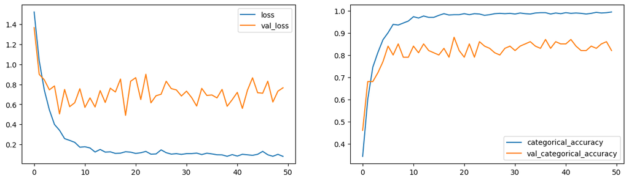

```python
model = Model_Pretrained_01(nb_classes = 5)
history = train_model(model, name = 'Pretrained_01')
plot_history(history)
```

```python
def Model_Pretrained_02(nb_classes):
    """
        ResNet50 + GRU
    """
    input_shape = (15, 128, 128, 3)
    weight_decay = 0.005
    nb_classes = nb_classes

    # load ResNet50 and freeze it
    resnet50_model = tf.keras.applications.vgg16.VGG16(weights='imagenet',
                                                       include_top=False,
                                                       input_shape=(dest_size[0], dest_size[1], 3))
    resnet50_model.trainable = False

    model = Sequential(name="Pretrained_02")
    model.add(TimeDistributed(resnet50_model,input_shape=input_shape))
    model.add(TimeDistributed(BatchNormalization()))
    model.add(TimeDistributed(MaxPooling2D((2, 2))))
    model.add(TimeDistributed(Flatten()))


    model.add(GRU(64, return_sequences=False))
    model.add(Dropout(0.25))

    model.add(Dense(32, activation='relu'))
    model.add(Dropout(0.25))

    # using Softmax as last layer
    model.add(Dense(nb_classes, activation='softmax'))

    return model
```

```
###############################################
Model Pretrained_02 summary
Model: "Pretrained_02"
_________________________________________________________________
 Layer (type)                Output Shape              Param #
=================================================================
 time_distributed_81 (TimeDi  (None, 15, 4, 4, 512)    14714688
 stributed)

 time_distributed_82 (TimeDi  (None, 15, 4, 4, 512)    2048
 stributed)

 time_distributed_83 (TimeDi  (None, 15, 2, 2, 512)    0
 stributed)

 time_distributed_84 (TimeDi  (None, 15, 2048)         0
 stributed)

 gru_4 (GRU)                 (None, 64)                405888

 dropout_20 (Dropout)        (None, 64)                0

 dense_19 (Dense)            (None, 32)                2080

 dropout_21 (Dropout)        (None, 32)                0

 dense_20 (Dense)            (None, 5)                 165

=================================================================
Total params: 15,124,869
Trainable params: 409,157
Non-trainable params: 14,715,712
_________________________________________________________________
None
###############################################
WARNING:tensorflow:`period` argument is deprecated. Please use `save_freq` to specify the frequency in number of batches seen.
###############################################
Training model
Epoch 1: val_loss improved from inf to 1.31100, saving model to ./checkpoints\model_Pretrained_02\model_Pretrained_02-00001-1.53584-0.32881-1.31100-0.60000.h5
Epoch 2: val_loss improved from 1.31100 to 1.04524, saving model to ./checkpoints\model_Pretrained_02\model_Pretrained_02-00002-1.08555-0.59276-1.04524-0.60000.h5
```

[output cut: 40 more lines]

```
Epoch 39: val_loss did not improve from 0.49767
Epoch 40: val_loss did not improve from 0.49767
Epoch 41: val_loss did not improve from 0.49767
Epoch 42: val_loss did not improve from 0.49767
Epoch 43: val_loss did not improve from 0.49767
Epoch 44: val_loss did not improve from 0.49767

Epoch 44: ReduceLROnPlateau reducing learning rate to 1.0000000656873453e-06.
Epoch 45: val_loss did not improve from 0.49767
Epoch 46: val_loss did not improve from 0.49767
Epoch 47: val_loss did not improve from 0.49767
Epoch 48: val_loss did not improve from 0.49767
Epoch 49: val_loss did not improve from 0.49767
Epoch 50: val_loss did not improve from 0.49767
###############################################
```

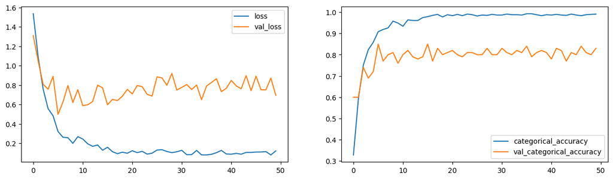

```python
model = Model_Pretrained_02(nb_classes = 5)
history = train_model(model, name = 'Pretrained_02')
plot_history(history)
```

### 2.3.3 EfficientNetv2B0 + GRU

```python
def Model_Pretrained_03(nb_classes):
    """
        ResNet50 + GRU
    """
    input_shape = (15, 128, 128, 3)
    weight_decay = 0.005
    nb_classes = nb_classes

    # load EfficientNetv2B0 and freeze it
    eff_model = tf.keras.applications.efficientnet_v2.EfficientNetV2B0(weights='imagenet',
                                                                       include_top=False,
                                                                       input_shape=(dest_size[0], dest_size[1], 3))
    eff_model.trainable = False

    model = Sequential(name="Pretrained_03")
    model.add(TimeDistributed(eff_model,input_shape=input_shape))
    model.add(TimeDistributed(BatchNormalization()))
    model.add(TimeDistributed(MaxPooling2D((2, 2))))
    model.add(TimeDistributed(Flatten()))


    model.add(GRU(64, return_sequences=False))
    model.add(Dropout(0.25))

    model.add(Dense(32, activation='relu'))
    model.add(Dropout(0.25))

    # using Softmax as last layer
    model.add(Dense(nb_classes, activation='softmax'))

    return model
```

```
###############################################
Model Pretrained_03 summary
Model: "Pretrained_03"
_________________________________________________________________
 Layer (type)                Output Shape              Param #
=================================================================
 time_distributed_85 (TimeDi  (None, 15, 4, 4, 1280)   5919312
 stributed)

 time_distributed_86 (TimeDi  (None, 15, 4, 4, 1280)   5120
 stributed)

 time_distributed_87 (TimeDi  (None, 15, 2, 2, 1280)   0
 stributed)

 time_distributed_88 (TimeDi  (None, 15, 5120)         0
 stributed)

 gru_5 (GRU)                 (None, 64)                995712

 dropout_22 (Dropout)        (None, 64)                0

 dense_21 (Dense)            (None, 32)                2080

 dropout_23 (Dropout)        (None, 32)                0

 dense_22 (Dense)            (None, 5)                 165

=================================================================
Total params: 6,922,389
Trainable params: 1,000,517
Non-trainable params: 5,921,872
_________________________________________________________________
None
###############################################
WARNING:tensorflow:`period` argument is deprecated. Please use `save_freq` to specify the frequency in number of batches seen.
###############################################
Training model
Epoch 1: val_loss improved from inf to 1.60929, saving model to ./checkpoints\model_Pretrained_03\model_Pretrained_03-00001-1.72586-0.19457-1.60929-0.24000.h5
Epoch 2: val_loss improved from 1.60929 to 1.60730, saving model to ./checkpoints\model_Pretrained_03\model_Pretrained_03-00002-1.63904-0.20513-1.60730-0.17000.h5
```

[output cut: 40 more lines]

```
Epoch 39: val_loss did not improve from 1.60665
Epoch 40: val_loss did not improve from 1.60665
Epoch 41: val_loss did not improve from 1.60665
Epoch 42: val_loss did not improve from 1.60665

Epoch 42: ReduceLROnPlateau reducing learning rate to 1.0000000656873453e-06.
Epoch 43: val_loss did not improve from 1.60665
Epoch 44: val_loss did not improve from 1.60665
Epoch 45: val_loss did not improve from 1.60665
Epoch 46: val_loss did not improve from 1.60665
Epoch 47: val_loss did not improve from 1.60665
Epoch 48: val_loss did not improve from 1.60665
Epoch 49: val_loss did not improve from 1.60665
Epoch 50: val_loss did not improve from 1.60665
###############################################
```

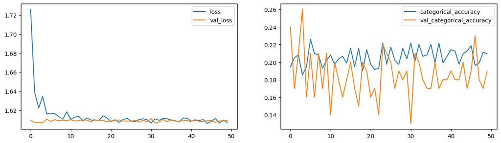

```python
model = Model_Pretrained_03(nb_classes = 5)
history = train_model(model, name = 'Pretrained_03')
plot_history(history)
```

### 2.3.4 EfficientNetv2B1 + GRU

```python
def Model_Pretrained_04(nb_classes):
    """
        ResNet50 + GRU
    """
    input_shape = (15, 128, 128, 3)
    weight_decay = 0.005
    nb_classes = nb_classes

    # load EfficientNetv2B1 and freeze it
    eff_model = tf.keras.applications.efficientnet_v2.EfficientNetV2B1(weights='imagenet',
                                                                       include_top=False,
                                                                       input_shape=(dest_size[0], dest_size[1], 3))
    eff_model.trainable = False

    model = Sequential(name="Pretrained_04")
    model.add(TimeDistributed(eff_model,input_shape=input_shape))
    model.add(TimeDistributed(BatchNormalization()))
    model.add(TimeDistributed(MaxPooling2D((2, 2))))
    model.add(TimeDistributed(Flatten()))


    model.add(GRU(64, return_sequences=False))
    model.add(Dropout(0.25))

    model.add(Dense(32, activation='relu'))
    model.add(Dropout(0.25))

    # using Softmax as last layer
    model.add(Dense(nb_classes, activation='softmax'))

    return model
```

```
###############################################
Model Pretrained_04 summary
Model: "Pretrained_04"
_________________________________________________________________
 Layer (type)                Output Shape              Param #
=================================================================
 time_distributed_89 (TimeDi  (None, 15, 4, 4, 1280)   6931124
 stributed)

 time_distributed_90 (TimeDi  (None, 15, 4, 4, 1280)   5120
 stributed)

 time_distributed_91 (TimeDi  (None, 15, 2, 2, 1280)   0
 stributed)

 time_distributed_92 (TimeDi  (None, 15, 5120)         0
 stributed)

 gru_6 (GRU)                 (None, 64)                995712

 dropout_24 (Dropout)        (None, 64)                0

 dense_23 (Dense)            (None, 32)                2080

 dropout_25 (Dropout)        (None, 32)                0

 dense_24 (Dense)            (None, 5)                 165

=================================================================
Total params: 7,934,201
Trainable params: 1,000,517
Non-trainable params: 6,933,684
_________________________________________________________________
None
###############################################
WARNING:tensorflow:`period` argument is deprecated. Please use `save_freq` to specify the frequency in number of batches seen.
###############################################
Training model
Epoch 1: val_loss improved from inf to 1.62483, saving model to ./checkpoints\model_Pretrained_04\model_Pretrained_04-00001-1.73491-0.19155-1.62483-0.19000.h5
Epoch 2: val_loss improved from 1.62483 to 1.61886, saving model to ./checkpoints\model_Pretrained_04\model_Pretrained_04-00002-1.64531-0.21267-1.61886-0.17000.h5
```

[output cut: 40 more lines]

```
Epoch 39: val_loss did not improve from 1.60311
Epoch 40: val_loss did not improve from 1.60311
Epoch 41: val_loss did not improve from 1.60311
Epoch 42: val_loss did not improve from 1.60311
Epoch 43: val_loss did not improve from 1.60311

Epoch 43: ReduceLROnPlateau reducing learning rate to 1.0000000656873453e-06.
Epoch 44: val_loss did not improve from 1.60311
Epoch 45: val_loss did not improve from 1.60311
Epoch 46: val_loss did not improve from 1.60311
Epoch 47: val_loss did not improve from 1.60311
Epoch 48: val_loss did not improve from 1.60311
Epoch 49: val_loss did not improve from 1.60311
Epoch 50: val_loss did not improve from 1.60311
###############################################
```

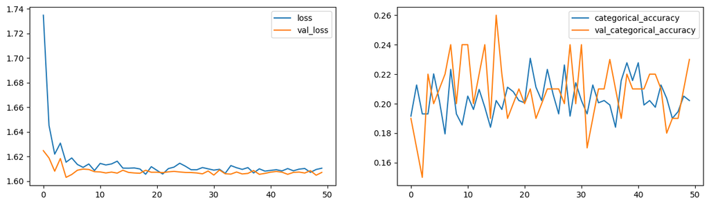

```python
model = Model_Pretrained_04(nb_classes = 5)
history = train_model(model, name = 'Pretrained_04')
plot_history(history)
```

Highest val_acc: at epoch 16: acc: 0.2021, val_acc: 0.2600

### 2.3.5 MobileNetv2 + GRU

```python
def Model_Pretrained_05(nb_classes):
    """
        MobileNetv2 + GRU
    """
    input_shape = (15, dest_size[0], dest_size[1], 3)
    weight_decay = 0.005
    nb_classes = nb_classes

    # load MobileNetv2 and freeze it
    mob_model = tf.keras.applications.mobilenet_v2.MobileNetV2(weights='imagenet',
                                                               include_top=False,
                                                               input_shape=(dest_size[0], dest_size[1], 3))
    mob_model.trainable = False
    model = Sequential(name="Pretrained_05")
    model.add(TimeDistributed(mob_model,input_shape=input_shape))
    model.add(TimeDistributed(BatchNormalization()))
    model.add(TimeDistributed(MaxPooling2D((2, 2))))
    model.add(TimeDistributed(Flatten()))


    model.add(GRU(64, return_sequences=False))
    model.add(Dropout(0.25))

    model.add(Dense(32, activation='relu'))
    model.add(Dropout(0.25))

    # using Softmax as last layer
    model.add(Dense(nb_classes, activation='softmax'))

    return model
```

```
###############################################
Model Pretrained_05 summary
Model: "Pretrained_05"
_________________________________________________________________
 Layer (type)                Output Shape              Param #
=================================================================
 time_distributed_93 (TimeDi  (None, 15, 4, 4, 1280)   2257984
 stributed)

 time_distributed_94 (TimeDi  (None, 15, 4, 4, 1280)   5120
 stributed)

 time_distributed_95 (TimeDi  (None, 15, 2, 2, 1280)   0
 stributed)

 time_distributed_96 (TimeDi  (None, 15, 5120)         0
 stributed)

 gru_7 (GRU)                 (None, 64)                995712

 dropout_26 (Dropout)        (None, 64)                0

 dense_25 (Dense)            (None, 32)                2080

 dropout_27 (Dropout)        (None, 32)                0

 dense_26 (Dense)            (None, 5)                 165

=================================================================
Total params: 3,261,061
Trainable params: 1,000,517
Non-trainable params: 2,260,544
_________________________________________________________________
None
###############################################
WARNING:tensorflow:`period` argument is deprecated. Please use `save_freq` to specify the frequency in number of batches seen.
###############################################
Training model
Epoch 1: val_loss improved from inf to 1.06285, saving model to ./checkpoints\model_Pretrained_05\model_Pretrained_05-00001-1.40465-0.41780-1.06285-0.66000.h5
Epoch 2: val_loss improved from 1.06285 to 0.78946, saving model to ./checkpoints\model_Pretrained_05\model_Pretrained_05-00002-0.83670-0.71192-0.78946-0.73000.h5
```

[output cut: 38 more lines]

```
Epoch 37: ReduceLROnPlateau reducing learning rate to 1.0000000474974514e-05.
Epoch 38: val_loss did not improve from 0.28994
Epoch 39: val_loss did not improve from 0.28994
Epoch 40: val_loss did not improve from 0.28994
Epoch 41: val_loss did not improve from 0.28994
Epoch 42: val_loss did not improve from 0.28994
Epoch 43: val_loss did not improve from 0.28994
Epoch 44: val_loss did not improve from 0.28994
Epoch 45: val_loss did not improve from 0.28994
Epoch 46: val_loss did not improve from 0.28994
Epoch 47: val_loss did not improve from 0.28994
Epoch 48: val_loss did not improve from 0.28994
Epoch 49: val_loss did not improve from 0.28994
Epoch 50: val_loss did not improve from 0.28994
###############################################
```

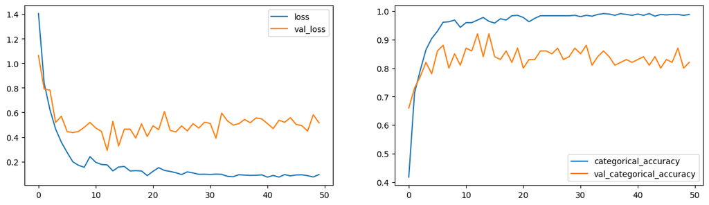

```python
model = Model_Pretrained_05(nb_classes = 5)
history = train_model(model, name = 'Pretrained_05', batch_size=20)
plot_history(history)
```

Highest val_acc: at epoch 15: acc: 0.9638, val_acc: 0.9200

### 2.3.6 Xception + GRU

```python
def Model_Pretrained_06(nb_classes):
    """
        Xception + GRU
    """
    input_shape = (15, dest_size[0], dest_size[1], 3)
    weight_decay = 0.005
    nb_classes = nb_classes

    # load MobileNetv2 and freeze it
    xcep_model = tf.keras.applications.xception.Xception(weights='imagenet',
                                                        include_top=False,
                                                        input_shape=(dest_size[0], dest_size[1], 3))
    xcep_model.trainable = False

    model = Sequential(name="Pretrained_06")
    model.add(TimeDistributed(xcep_model,input_shape=input_shape))
    model.add(TimeDistributed(BatchNormalization()))
    model.add(TimeDistributed(MaxPooling2D((2, 2))))
    model.add(TimeDistributed(Flatten()))


    model.add(GRU(64, return_sequences=False))
    model.add(Dropout(0.25))

    model.add(Dense(32, activation='relu'))
    model.add(Dropout(0.25))

    # using Softmax as last layer
    model.add(Dense(nb_classes, activation='softmax'))

    return model
```

```
###############################################
Model Pretrained_06 summary
Model: "Pretrained_06"
_________________________________________________________________
 Layer (type)                Output Shape              Param #
=================================================================
 time_distributed_97 (TimeDi  (None, 15, 4, 4, 2048)   20861480
 stributed)

 time_distributed_98 (TimeDi  (None, 15, 4, 4, 2048)   8192
 stributed)

 time_distributed_99 (TimeDi  (None, 15, 2, 2, 2048)   0
 stributed)

 time_distributed_100 (TimeD  (None, 15, 8192)         0
 istributed)

 gru_8 (GRU)                 (None, 64)                1585536

 dropout_28 (Dropout)        (None, 64)                0

 dense_27 (Dense)            (None, 32)                2080

 dropout_29 (Dropout)        (None, 32)                0

 dense_28 (Dense)            (None, 5)                 165

=================================================================
Total params: 22,457,453
Trainable params: 1,591,877
Non-trainable params: 20,865,576
_________________________________________________________________
None
###############################################
WARNING:tensorflow:`period` argument is deprecated. Please use `save_freq` to specify the frequency in number of batches seen.
###############################################
Training model
Epoch 1: val_loss improved from inf to 1.22988, saving model to ./checkpoints\model_Pretrained_06\model_Pretrained_06-00001-1.51092-0.39970-1.22988-0.53000.h5
Epoch 2: val_loss improved from 1.22988 to 1.08619, saving model to ./checkpoints\model_Pretrained_06\model_Pretrained_06-00002-1.19324-0.52338-1.08619-0.54000.h5
```

[output cut: 38 more lines]

```
Epoch 37: ReduceLROnPlateau reducing learning rate to 1.0000000474974514e-05.
Epoch 38: val_loss did not improve from 0.73637
Epoch 39: val_loss did not improve from 0.73637
Epoch 40: val_loss did not improve from 0.73637
Epoch 41: val_loss did not improve from 0.73637
Epoch 42: val_loss did not improve from 0.73637
Epoch 43: val_loss did not improve from 0.73637
Epoch 44: val_loss did not improve from 0.73637
Epoch 45: val_loss did not improve from 0.73637
Epoch 46: val_loss did not improve from 0.73637
Epoch 47: val_loss did not improve from 0.73637
Epoch 48: val_loss improved from 0.73637 to 0.66155, saving model to ./checkpoints\model_Pretrained_06\model_Pretrained_06-00048-0.28527-0.92308-0.66155-0.70000.h5
Epoch 49: val_loss did not improve from 0.66155
Epoch 50: val_loss did not improve from 0.66155
###############################################
```

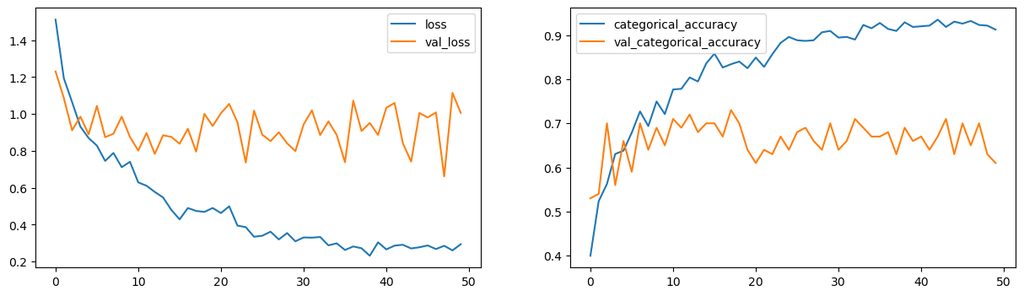

```python
model = Model_Pretrained_06(nb_classes = 5)
history = train_model(model, name = 'Pretrained_06', batch_size=8)
plot_history(history)
```

### 2.3.7 MobilenetV2 + LSTM

We found that Mobilenet + GRU is the best model amond all the models we trained, now try mobilenet + LSTM

```python
def Model_Pretrained_07(nb_classes):
    """
        MobileNetv2 + GRU
    """
    input_shape = (15, dest_size[0], dest_size[1], 3)
    weight_decay = 0.005
    nb_classes = nb_classes

    # load MobileNetv2 and freeze it
    mob_model = tf.keras.applications.mobilenet_v2.MobileNetV2(weights='imagenet',
                                                               include_top=False,
                                                               input_shape=(dest_size[0], dest_size[1], 3))
    mob_model.trainable = False
    model = Sequential(name="Pretrained_07")
    model.add(TimeDistributed(mob_model,input_shape=input_shape))
    model.add(TimeDistributed(BatchNormalization()))
    model.add(TimeDistributed(MaxPooling2D((2, 2))))
    model.add(TimeDistributed(Flatten()))


    model.add(LSTM(64, return_sequences=False))
    model.add(Dropout(0.25))

    model.add(Dense(32, activation='relu'))
    model.add(Dropout(0.25))

    # using Softmax as last layer
    model.add(Dense(nb_classes, activation='softmax'))

    return model
```

```
###############################################
Model Pretrained_07 summary
Model: "Pretrained_07"
_________________________________________________________________
 Layer (type)                Output Shape              Param #
=================================================================
 time_distributed_101 (TimeD  (None, 15, 4, 4, 1280)   2257984
 istributed)

 time_distributed_102 (TimeD  (None, 15, 4, 4, 1280)   5120
 istributed)

 time_distributed_103 (TimeD  (None, 15, 2, 2, 1280)   0
 istributed)

 time_distributed_104 (TimeD  (None, 15, 5120)         0
 istributed)

 lstm_2 (LSTM)               (None, 64)                1327360

 dropout_30 (Dropout)        (None, 64)                0

 dense_29 (Dense)            (None, 32)                2080

 dropout_31 (Dropout)        (None, 32)                0

 dense_30 (Dense)            (None, 5)                 165

=================================================================
Total params: 3,592,709
Trainable params: 1,332,165
Non-trainable params: 2,260,544
_________________________________________________________________
None
###############################################
WARNING:tensorflow:`period` argument is deprecated. Please use `save_freq` to specify the frequency in number of batches seen.
###############################################
Training model
Epoch 1: val_loss improved from inf to 1.11965, saving model to ./checkpoints\model_Pretrained_07\model_Pretrained_07-00001-1.45112-0.40573-1.11965-0.64000.h5
Epoch 2: val_loss improved from 1.11965 to 0.72736, saving model to ./checkpoints\model_Pretrained_07\model_Pretrained_07-00002-1.01356-0.64706-0.72736-0.81000.h5
```

[output cut: 38 more lines]

```
Epoch 39: val_loss did not improve from 0.37019
Epoch 40: val_loss did not improve from 0.37019
Epoch 41: val_loss did not improve from 0.37019
Epoch 42: val_loss did not improve from 0.37019
Epoch 43: val_loss did not improve from 0.37019
Epoch 44: val_loss did not improve from 0.37019
Epoch 45: val_loss did not improve from 0.37019
Epoch 46: val_loss did not improve from 0.37019
Epoch 47: val_loss did not improve from 0.37019
Epoch 48: val_loss did not improve from 0.37019

Epoch 48: ReduceLROnPlateau reducing learning rate to 1.0000000474974514e-05.
Epoch 49: val_loss did not improve from 0.37019
Epoch 50: val_loss did not improve from 0.37019
###############################################
```

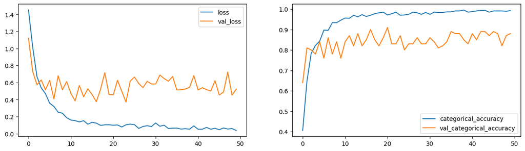

```python
model = Model_Pretrained_07(nb_classes = 5)
history = train_model(model, name = 'Pretrained_07', batch_size=4)
plot_history(history)
```

## 3. Conclusion

If you on edge device, we can chooise model CNN_03, because it only have total 200000 para, very light weight but still good enough (87% val acc)

For further improvement, we may need more data, data augmentation, larger batch_size